# Generalized Canonical Correlation with missing individuals

Dolors Pelegri-Siso, Isaac Subirana and Juan R. Gonzalez

Institute for Global Health (ISGlobal), Barcelona, Spain Bioinformatics Research Group in Epidemiolgy (BRGE) http://brge.isglobal.org

2020-09-14

#### Package

mgcca 0.9.9

# 1 Introduction

This manual describes how to peform a Regularized Generalized Canonical Correlation Analysis analysis and then how to perform the same data analysis with missing Canonical Correlation Analysis analysis method implemented in mgcca function in this package.

# 2 Getting started

`mgcca` package depends on `BigDataStatMeth` packages so in orther to install `mgcca` we need to install it.

```r
devtools::install_github("isglobal-brge/BigDataStatMeth")
```

The development version of `mgcca` package can be installed from BRGE GitHub repository:

```r
devtools::install_github("isglobal-brge/mgcca")
```

The package depends on other R/Bioc packages that can be installed using standard functions (`install.packages` and/or `biocLite`). Then, the package can be loaded into R as usual

```r
library(mgcca)
```

This vignette uses data from different packages such as `RGCCA` from CRAN and `omicade4` from Bioconductor with commands,

```r
# Install RGCCA
install.packages("RGCCA")

# Install omicade4
if (!requireNamespace("BiocManager", quietly = TRUE))
    install.packages("BiocManager")

BiocManager::install("omicade4")
```

# 3 Canonical correlation

```r
library(RGCCA)
data(Russett, package="RGCCA")
Xagric <- as.matrix(Russett[,c("gini","farm","rent")])
Xind <- as.matrix(Russett[,c("gnpr","labo")])
Xpolit <- as.matrix(Russett[ , c("inst", "ecks", "death")])
X <- list(Xagric=Xagric, Xind=Xind, Xpolit=Xpolit)
```

```r
labs <- rownames(Russett)
group <- as.vector(apply(Russett[, c("demostab", "demoinst", "dictator")],
                       1, which.max))
names(group) <- labs
```

```r
Russett.sel <- cbind(Xagric, Xind, Xpolit)
X.rgcca <- X
X.rgcca[[4]] <- Russett.sel
C <- matrix(c(0, 0, 0, 1, 0, 0, 0, 1, 0, 0, 0, 1, 1, 1, 1, 0), 4, 4)
res.rgcca <- rgcca(X.rgcca, C, tau = c(0, 0, 0, 0), ncomp = rep(2, 4),
                   scheme = "factorial", scale = TRUE, verbose=FALSE)
```

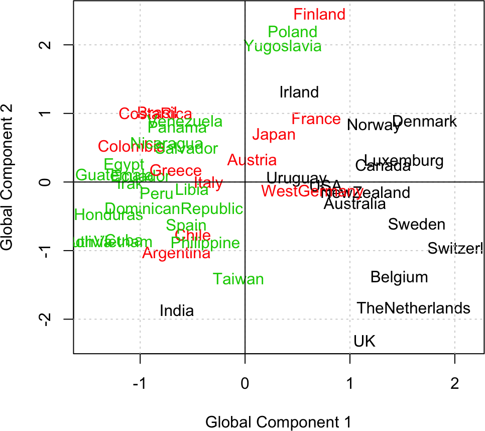

```r
plot(res.rgcca$Y[[4]][, 1], res.rgcca$Y[[4]][, 2], type = "n",
     xlab = "Global Component 1", ylab = "Global Component 2")
text(res.rgcca$Y[[4]][, 1], res.rgcca$Y[[4]][, 2], labs, col = group)
grid()
abline(h=0)
abline(v=0)
```

```r
corr <- cor(Russett.sel, res.rgcca$Y[[4]])
```

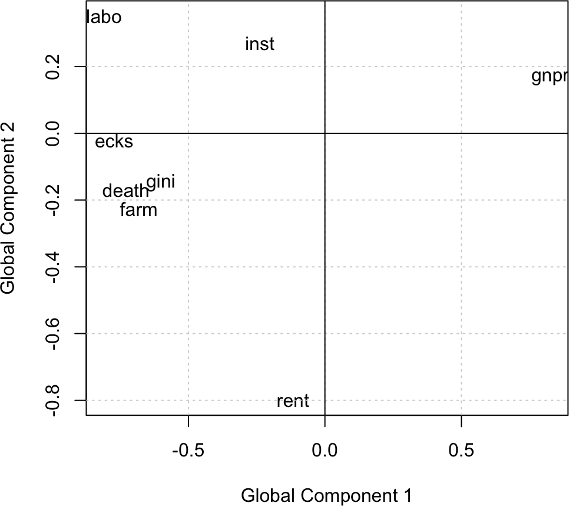

```r
plot(corr[,1], corr[, 2], type = "n",
     xlab = "Global Component 1", ylab = "Global Component 2")
text(corr[, 1], corr[, 2], rownames(corr))
grid()
abline(h=0)
abline(v=0)
```

```r
res.mgcca <- mgcca(X)
```

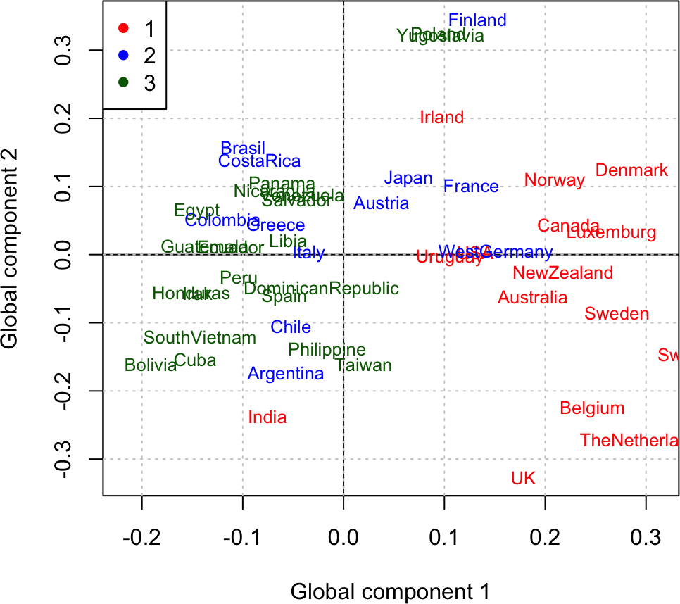

```r
plotInds(res.mgcca, group=as.factor(group), print.labels = TRUE,
        pos.leg="topleft")
```

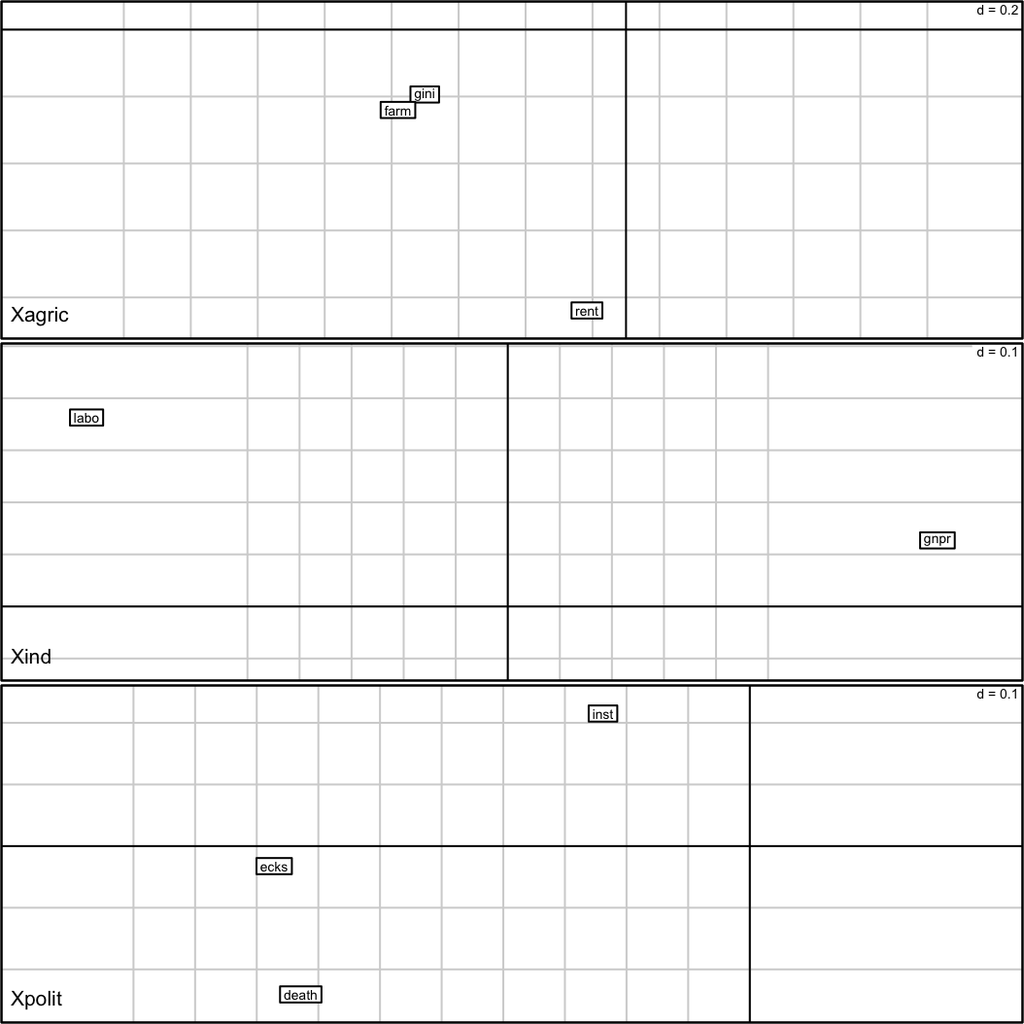

```r
plotVars(res.mgcca, nlab=5)
```

# 4 Reguralized canonical correlation: the `omic` case

The nutrimouse dataset comes from a nutrition study in the mouse. It was provided by Pascal Martin from the Toxicology and Pharmacology Laboratory (French National Institute for Agronomic Research) and is available at R package `CCA`. It contains information on 40 mouse for two tables and a grouping variable having wild-type and PPARalpha -/- genotypes. Such information can be retrieved into R by:

```r
library(CCA)
data(nutrimouse, package = "CCA")
X <- as.matrix(nutrimouse$gene)
Y <- as.matrix(nutrimouse$lipid)
group <- nutrimouse$genotype
```

Table X includes gene expresion on 120 genes potentially involved in nutritional problems, while table Y contains concentration of 21 hepatic fatty acids concentration.

```r
dim(X)
```

```
## [1]  40 120
```

```r
dim(Y)
```

```
## [1] 40 21
```

```r
table(group)
```

```
## group
##   wt ppar
##   20   20
```

```r
X.s <- scale(X)
Y.s <- scale(Y)
lambda.est <- estim.regul(X.s, Y.s, plt=FALSE)
```

```
##   lambda1 =  0.5005
##   lambda2 =  0.001
##  CV-score =  0.9698361
```

```r
res.rcca <- rcc(X.s, Y.s, lambda.est[1], lambda.est[2])
```

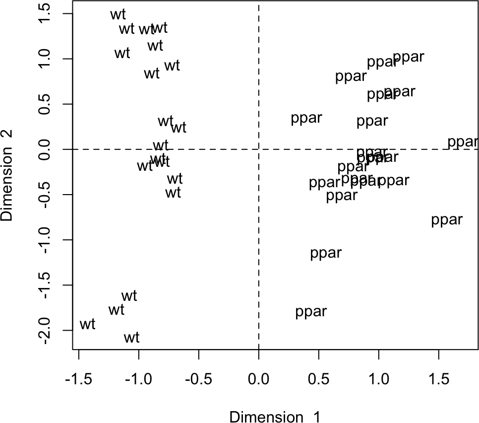

```r
plt.indiv(res.rcca, 1, 2, ind.names = group)
```

```r
XX <- list(genes=X.s, lipids=Y.s)
ll <- c(lambda.est$lambda1, lambda.est$lambda2)
res.mgcca <- mgcca(XX, method = "penalized", lambda=c(0.001, 0.1))
```

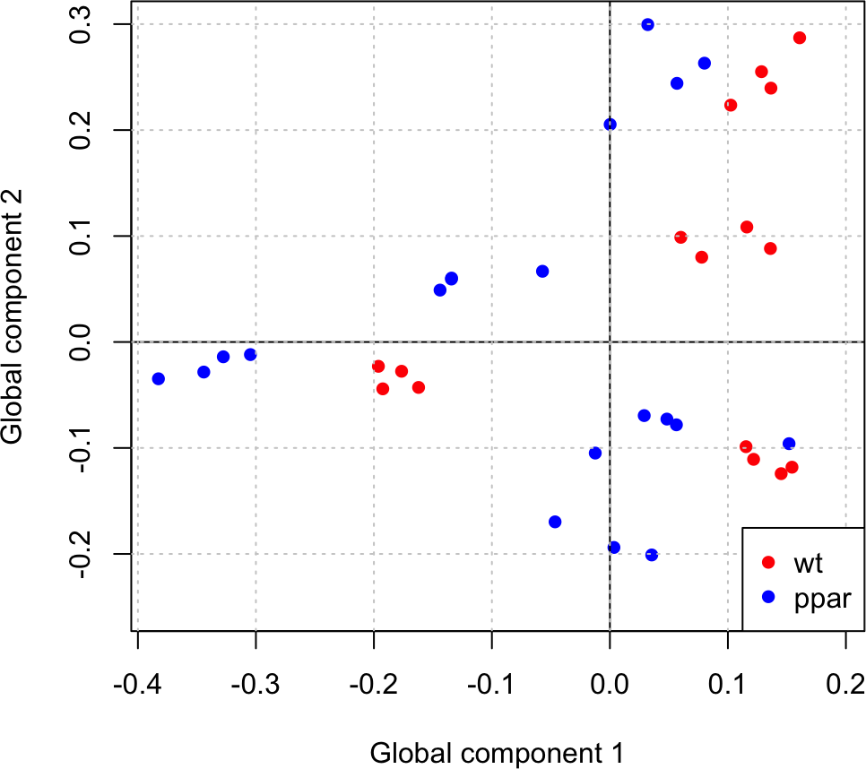

```r
plotInds(res.mgcca, group=group)
```

```r
X.rgcca <- list(X, Y, cbind(X,Y))
C <- matrix(c(0, 0,  1, 0, 0, 1, 1, 1, 0), 3, 3)
res.rgcca <- rgcca(X.rgcca, C, tau = c(0, 0, 0), ncomp = rep(2, 3),
                   scheme = "factorial", scale = TRUE, verbose=FALSE)
```

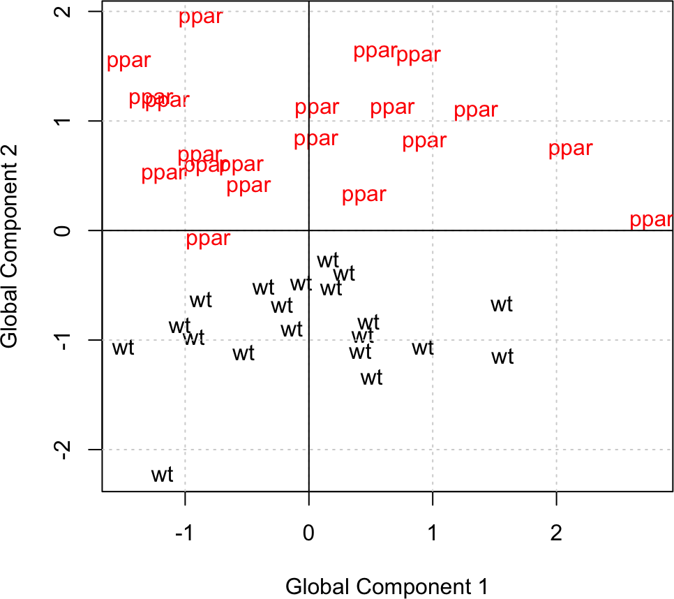

```r
plot(res.rgcca$Y[[3]][, 1], res.rgcca$Y[[3]][, 2], type = "n",
     xlab = "Global Component 1", ylab = "Global Component 2")
text(res.rgcca$Y[[3]][, 1], res.rgcca$Y[[3]][, 2], group, col = as.numeric(group))
grid()
abline(h=0)
abline(v=0)
```

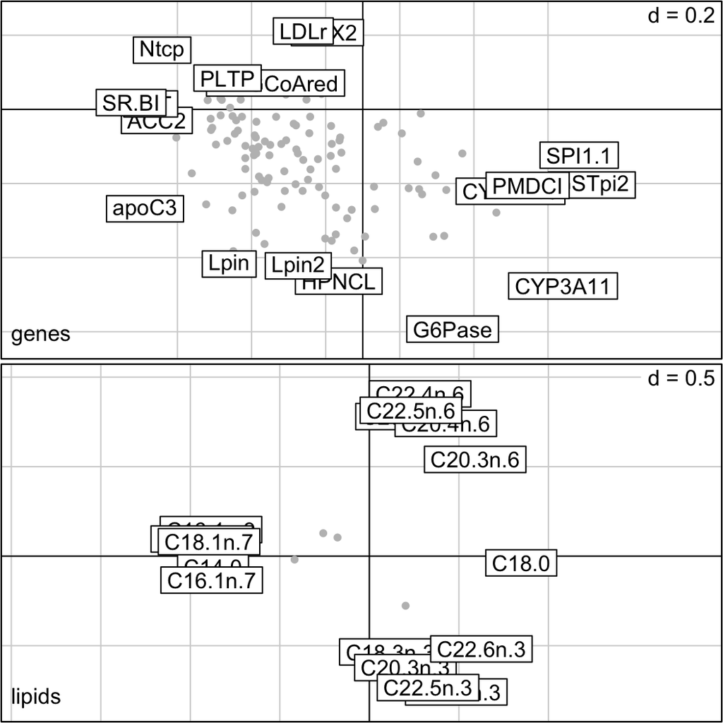

```r
plotVars(res.mgcca, nlab=5)
```

```r
getSignif(res.mgcca, pval=1e-3, df="genes")
```

```
##    variable table
## 1      ACC2 genes
## 2   CYP3A11 genes
## 3       FAT genes
## 4    G6Pase genes
## 5    GSTpi2 genes
## 6      Ntcp genes
## 7    SPI1.1 genes
## 8     SR.BI genes
## 9      UCP2 genes
## 10    apoC3 genes
```

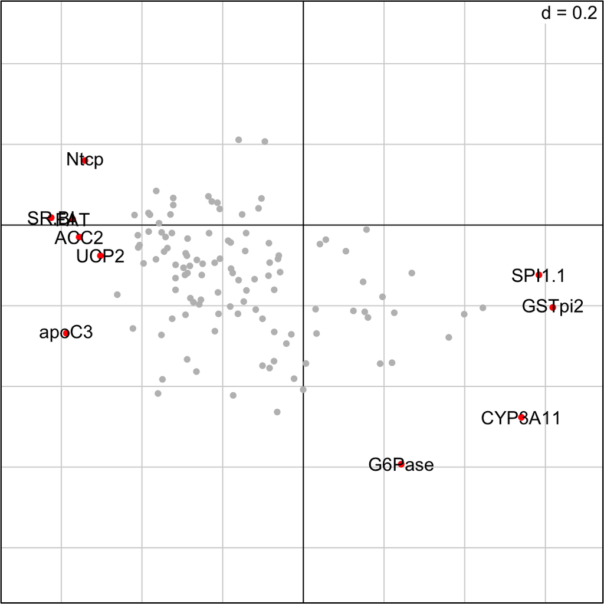

```r
var.signif <- getSignif(res.mgcca, pval=1e-3, df="genes")$variable
plotVars(res.mgcca, var=var.signif, var.col = rep("red", length(var.signif)),
         var.lab=TRUE, df="genes")
```

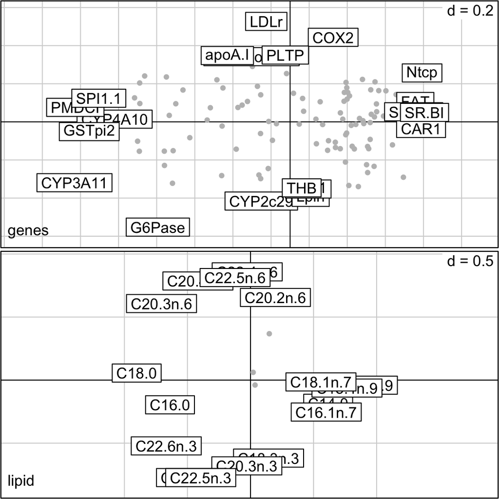

```r
library(omicade4)
res.mcia <- mcia(list(genes=t(X.s), lipid=t(Y.s)))
plotVar(res.mcia, nlab=5)
```

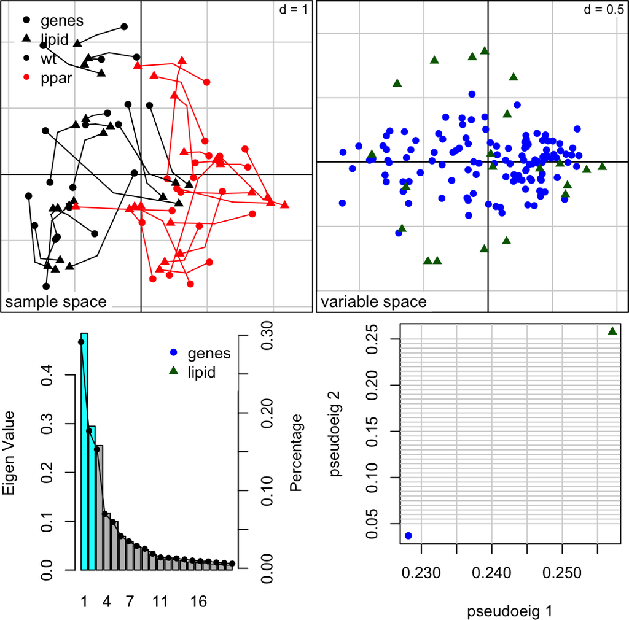

```r
plot(res.mcia, phenovec=group, sample.lab=FALSE, df.color=c("blue", "darkgreen"))
```

# 5 Generalized Canonical Correlation with missing individuals